# What’s in your signature, Stan?

Deemah

2/11/2021

```r
data_url <- "https://raw.githubusercontent.com/avehtari/BDA_R_demos/master/demos_rstan/gpareto_functions/geomagnetic_tail_data.csv"

d <- read.csv(data_url, header = FALSE)
colnames(d) <- "dst"
d$dst <- sort(abs(d$dst))

n <- nrow(d)
d$ccdf <- seq(n, 1, -1)/n
head(d)
```

```
##   dst      ccdf
## 1 100 1.0000000
## 2 100 0.9973190
## 3 100 0.9946381
## 4 100 0.9919571
## 5 100 0.9892761
## 6 100 0.9865952
```

# Introduction

## Objective

Understand math and reimplement Aki Vehtari’s Generalized Pareto distribution tutorial.

Define a Generalized Pareto PDF

NOTE: Aki’s document contains a typo in the function definition for $k=0$

$$f(y|u,\sigma,k)=\begin{cases}
\frac{1}{\sigma}(1+k(\frac{y-u}{\sigma}))^{-\frac{1}{k}-1}, \; k \ne 0 \\
\frac{1}{\sigma}\text{exp}(-\frac{y-u}{\sigma}), \quad \qquad , \; k = 0, \\
\end{cases}$$

where $u$ is a lower bound parameter, $\sigma$ is a scale parameter, $k$ is shape parameter and $y$ is the data restricted to the range $(u, \inf)$.

In order to match Stan’s math library we need to implement the following functions:

- `_lpdf` (or `_lpmf`): log probability density (or log probability mass) function (aka “density function”)
- `_cdf`: cumulative density function (aka “probability function”)
- `_lcdf`: log cumulative density function
- `_lccdf`: log complimentary cumulative density function (“exceedance function”)
- `_rng`: random number generator from the distribution.

> Unlike the functions implemented in the C++ Stan math library, the user defined functions can have only signature.

What Aki means is that we will either define vectorized functions (taking in a vector of `y`) or non-vectorized functions (taking individual values of `y`), not both. It is possible for functions in C++ to have flexible signature, but users defining their functions in Stan directly do not have that luxury. Let’s first follow along and define these functions with vectorized signature, as Aki does it. Aki explains:

> I have chosen to have *vector* type for `y` and *real* types for the parameters, while built-in functions can handle vectors, arrays and scalars (denoted by generic type `reals`).

Choosing a vector-valued `y` has no implication on what the function returns. It will still return a single *real* value, as we will compute the *sum of log values* for each `y` in `_lcdf`, `_lccdf`, `_lpdf`, and a *product of values* for each `y` in the `_cdf`. The `_rng` is always returning a single random number.

## lpdf

$$\sum_{i=1}^{N}ln(\frac{1}{\sigma}(1+k(\frac{y-u}{\sigma}))^{-\frac{1}{k}-1})=$$
$$\sum_{i=1}^{N} -(\frac{1}{k}+1)*ln(\frac{1}{\sigma}(1+k(\frac{y-u}{\sigma})))=$$
$$-(\frac{1}{k}+1) \sum_{i=1}^{N} ln(1+k(\frac{y-u}{\sigma}))-\sum_{i=1}^{N}ln(\sigma)=$$
$$-(1+k^{-1}) \sum_{i=1}^{N} ln(1+(y-u)\frac{k}{\sigma})-Nln(\sigma)=$$

And for $k=0$

$$\sum_{i=1}^{N}ln(\frac{1}{\sigma}\text{exp}(-\frac{y-u}{\sigma}))=$$
$$-\sum_{i=1}^{N} \frac{y-u}{\sigma}-\sum_{i=1}^{N} ln(\sigma)=$$
$$-\frac{\sum_{i=1}^{N}(y-u)}{\sigma}-N*ln(\sigma)$$
This is what (literally) gets implemented in the code below.

NOTE: I am not sure where the minus sign comes from in the second equation.

```stan
  real gpareto_lpdf(vector y, real ymin, real k, real sigma) {
    // generalised Pareto log pdf
    int N = rows(y);
    real inv_k = inv(k);
    if (k<0 && max(y-ymin)/sigma > -inv_k)
      reject("k<0 and max(y-ymin)/sigma > -1/k; found k, sigma =", k, sigma)
    if (sigma<=0)
      reject("sigma<=0; found sigma =", sigma)
    if (fabs(k) > 1e-15)
      return -(1+inv_k)*sum(log1p((y-ymin) * (k/sigma))) -N*log(sigma);
    else
      return -sum(y-ymin)/sigma -N*log(sigma); // limit k->0
  }
```

## cdf

Wikipedia article says the formula for the GPD CDF is
$$F(y|u,\sigma,k)=\begin{cases}1-(1+k(\frac{y-u}{\sigma}))^{-1/k}, k \ne 0\\
1-\text{exp}(-\frac{y-u}{\sigma}), k=0
\end{cases}$$
Let’s see how this got translated into the code. As mentioned before we need a *product* of elements for every `y`. The easiest way to accomplish is is to `exp(sum(log()))`. Lets take each of the cases separately. For $k \ne 0$:

$$\exp(\sum_{i=1}^Nln(1-(1+k(\frac{y-u}{\sigma}))^{-1/k}))=$$
We need to somehow deal with the power inside of our logarithm. Whenever you see expression powered, like $a^b$ it is useful to log and exp it, so that you can go from $a^b=exp(log(a^b))$, because then you can just $a^b=exp(log(a^b))=exp(b*log(a))$ and be done with the power. We will use the same trick here:

$$\exp(\sum_{i=1}^Nln(1-\text{exp}(ln(1+k(\frac{y-u}{\sigma}))^{-1/k})))=$$
$$\exp(\sum_{i=1}^Nln(1-\text{exp}(-1/k*ln(1+(\frac{k}{\sigma})*(y-u)))))=$$
Here it is important to [remind](https://mc-stan.org/docs/2_21/functions-reference/composed-functions.html) that in STAN `log1m_exp(x)` returns `log(1-exp(x))` if $x<0$ and $NaN$ otherwise.

For $k = 0$ the formula we need to implement will be

$$exp(\sum_{i=1}^{N}ln(1-\text{exp}(-\frac{y-u}{\sigma}))=$$

```stan
  real gpareto_cdf(vector y, real ymin, real k, real sigma) {
    // generalised Pareto cdf
    real inv_k = inv(k);
    if (k<0 && max(y-ymin)/sigma > -inv_k)
      reject("k<0 and max(y-ymin)/sigma > -1/k; found k, sigma =", k, sigma)
    if (sigma<=0)
      reject("sigma<=0; found sigma =", sigma)
    if (fabs(k) > 1e-15)
      return exp(sum(log1m_exp((-inv_k)*(log1p((y-ymin) * (k/sigma))))));
    else
      return exp(sum(log1m_exp(-(y-ymin)/sigma))); // limit k->0
  }
```

## lcdf

Here we need to compute sum of log values of $cdf$ function
$$F(y|u,\sigma,k)=\begin{cases}1-(1+k(\frac{y-u}{\sigma}))^{-1/k}, k \ne 0\\
1-\text{exp}(-\frac{y-u}{\sigma}), k=0
\end{cases}$$

Therefore, for $k \ne 0$:

$$\sum_{i=1}^{N}ln(1-(1+k(\frac{y-u}{\sigma}))^{-1/k})=$$
We will use the same trick here $a^b=exp(log(a^b))=exp(b*log(a))$

$$\sum_{i=1}^{N}ln(1-exp(-1/k*ln(1+(y-u)*(\frac{k}{\sigma}))))$$
And for $k = 0$:

$$\sum_{i=1}^{N}ln(1-\text{exp}(-\frac{y-u}{\sigma}))$$

```stan
  real gpareto_lcdf(vector y, real ymin, real k, real sigma) {
    // generalised Pareto log cdf
    real inv_k = inv(k);
    if (k<0 && max(y-ymin)/sigma > -inv_k)
      reject("k<0 and max(y-ymin)/sigma > -1/k; found k, sigma =", k, sigma)
    if (sigma<=0)
      reject("sigma<=0; found sigma =", sigma)
    if (fabs(k) > 1e-15)
      return sum(log1m_exp((-inv_k)*(log1p((y-ymin) * (k/sigma)))));
    else
      return sum(log1m_exp(-(y-ymin)/sigma)); // limit k->0
  }
```

## lccdf

Log of complimentary cdf (the exceedance function) is merely $1-F(y|u,\sigma,k)$, so adjusting our formula should be straightforward:

$$1-F(y|u,\sigma,k)=\begin{cases}(1+k(\frac{y-u}{\sigma}))^{-1/k}, k \ne 0\\ \text{exp}(-\frac{y-u}{\sigma}), k=0 \end{cases}$$

Therefore, for $k \ne 0$

$$\sum_{i=1}^{N} ln((1+k(\frac{y-u}{\sigma}))^{-1/k})$$
$$-1/k*\sum_{i=1}^{N} ln(1+\frac{k}{\sigma}(y-u))$$
and for $k = 0$

$$\sum_{i=1}^{N}ln(\text{exp}(-\frac{y-u}{\sigma}))=$$
$$-\frac{\sum_{i=1}^{N}(y-u)}{\sigma}$$

```stan
   real gpareto_lccdf(vector y, real ymin, real k, real sigma) {
    // generalised Pareto log ccdf
    real inv_k = inv(k);
    if (k<0 && max(y-ymin)/sigma > -inv_k)
      reject("k<0 and max(y-ymin)/sigma > -1/k; found k, sigma =", k, sigma)
    if (sigma<=0)
      reject("sigma<=0; found sigma =", sigma)
    if (fabs(k) > 1e-15)
      return (-inv_k)*sum(log1p((y-ymin) * (k/sigma)));
    else
      return -sum(y-ymin)/sigma; // limit k->0
  }
```

## rng

Finally for random number generator, we can use GPD quantile function, which is the inverted CCDF.

$$1-F(y|u,\sigma,k)=\begin{cases}(1+k(\frac{y-u}{\sigma}))^{-1/k}, k \ne 0\\
\text{exp}(-\frac{y-u}{\sigma}), k=0
\end{cases}$$

Let’s invert these cases one at a time. First for $k \ne 0$ we have:

$$v=\left(1+k(\frac{Q-u}{\sigma})\right)^{-1/k}$$
$$v=\left(\frac{\sigma+kQ-ku}{\sigma}\right)^{-1/k}$$
$$v\sigma^{-1/k}=(\sigma+kQ-ku)^{-1/k}$$

$$(v\sigma^{-1/k})^{-k}=((\sigma+kQ-ku)^{-1/k})^{-k}$$

$$v^{-k}\sigma=\sigma+kQ-ku$$

$$Q=\frac{v^{-k}\sigma-\sigma + ku}{k}$$

$$Q=\frac{\sigma(v^{-k}-1)}{k}+u=u+(v^{-k}-1)*\sigma/k$$

For $k=0$ we have

$$v=\text{exp}(-\frac{Q-u}{\sigma})$$

$$v=\text{exp}(-\frac{Q-u}{\sigma})$$

$$v=\text{exp}(-\frac{Q-u}{\sigma})$$

$$ln(v)=-\frac{Q-u}{\sigma}$$
$$\sigma*ln(v)=-Q+u$$

$$Q=u-\sigma*ln(v)$$
Which is what is implemented here:

```stan
  real gpareto_rng(real ymin, real k, real sigma) {
    // generalised Pareto rng
    if (sigma<=0)
      reject("sigma<=0; found sigma =", sigma)
    if (fabs(k) > 1e-15)
      return ymin + (uniform_rng(0,1)^-k -1) * sigma / k;
    else
      return ymin - sigma*log(uniform_rng(0,1)); // limit k->0
  }
```

## Data and model

We will need the following parameters in our model $u$ called `ymin`, $\sigma$ called sigma and $k$ called `k`. Note that `ymin` will be static and defined by the user, therefore we will put it into the *data* block. The other two parameters will be inferred from data, therefore we will put them into the *parameter* block of our program. We will also need data itself, denoted by $y$, as well as the usually provided $N$, which is the total number of observations. Never mind $Nt$ and $yt$ for now. They are copies of $N$ and $y$ that will be used for prior predictive checks.

```stan
data {
  real ymin;
  int<lower=0> N;
  vector<lower=ymin>[N] y;
  int<lower=0> Nt;
  vector<lower=ymin>[Nt] yt;
}
transformed data {
  real ymax = max(y);
}
parameters {
  real<lower=0> sigma;
  real<lower=-sigma/(ymax-ymin)> k;
}
model {
  y ~ gpareto(ymin, k, sigma);
}
```

There are couple of things to note about this model specification. `ymax` is computed on the fly from data for the purpose of validating $k$. Therefore it could either be provided as its own data point or, as done here, go into (and be calculated in) the *transformed data* block.

The model specification says that $y$ will be “distributed as” $gpareto()$. Wait, we have never defined a function with this name! When the expression is used in this notation (i.e. using the formula syntax with `~` sign), the function with suffix `_lpdf` will be searched and called. Also note that in our `gpareto_lpdf()` function, the first argument is $y$. In the “formula” notation, the first argument will appear on the other side of the `~`. That is because the the proper notation should use the `target` variable and `+=` operator inside the loop. Have a look at the documentation for more details (I am not providing it here to minimize confusion).

We will now add the prior predictive checks section without any modifications.

```stan
generated quantities {
  vector[N] log_lik;
  vector[N] yrep;
  vector[Nt] predccdf;
  for (n in 1:N) {
    log_lik[n] = gpareto_lpdf(rep_vector(y[n],1) | ymin, k, sigma);
    yrep[n] = gpareto_rng(ymin, k, sigma);
  }
  for (nt in 1:Nt)
    predccdf[nt] = exp(gpareto_lccdf(rep_vector(yt[nt],1) | ymin, k, sigma));
}
```

There are a few “gotchas” in the *generated quantities* section, that Aki explains in his post. Have a [look](https://mc-stan.org/users/documentation/case-studies/gpareto_functions.html).

```
## functions{ // begin the functions block
##   real gpareto_lpdf(vector y, real ymin, real k, real sigma) {
##     // generalised Pareto log pdf
##     int N = rows(y);
##     real inv_k = inv(k);
##     if (k<0 && max(y-ymin)/sigma > -inv_k)
##       reject("k<0 and max(y-ymin)/sigma > -1/k; found k, sigma =", k, sigma)
##     if (sigma<=0)
##       reject("sigma<=0; found sigma =", sigma)
##     if (fabs(k) > 1e-15)
##       return -(1+inv_k)*sum(log1p((y-ymin) * (k/sigma))) -N*log(sigma);
##     else
##       return -sum(y-ymin)/sigma -N*log(sigma); // limit k->0
##   }
##   real gpareto_cdf(vector y, real ymin, real k, real sigma) {
##     // generalised Pareto cdf
##     real inv_k = inv(k);
##     if (k<0 && max(y-ymin)/sigma > -inv_k)
##       reject("k<0 and max(y-ymin)/sigma > -1/k; found k, sigma =", k, sigma)
##     if (sigma<=0)
##       reject("sigma<=0; found sigma =", sigma)
##     if (fabs(k) > 1e-15)
##       return exp(sum(log1m_exp((-inv_k)*(log1p((y-ymin) * (k/sigma))))));
##     else
##       return exp(sum(log1m_exp(-(y-ymin)/sigma))); // limit k->0
##   }
##   real gpareto_lcdf(vector y, real ymin, real k, real sigma) {
##     // generalised Pareto log cdf
##     real inv_k = inv(k);
##     if (k<0 && max(y-ymin)/sigma > -inv_k)
##       reject("k<0 and max(y-ymin)/sigma > -1/k; found k, sigma =", k, sigma)
##     if (sigma<=0)
##       reject("sigma<=0; found sigma =", sigma)
##     if (fabs(k) > 1e-15)
##       return sum(log1m_exp((-inv_k)*(log1p((y-ymin) * (k/sigma)))));
##     else
##       return sum(log1m_exp(-(y-ymin)/sigma)); // limit k->0
##   }
##    real gpareto_lccdf(vector y, real ymin, real k, real sigma) {
##     // generalised Pareto log ccdf
```

[output cut: 33 more lines]

```
## }
## model {
##   y ~ gpareto(ymin, k, sigma);
## }
## generated quantities {
##   vector[N] log_lik;
##   vector[N] yrep;
##   vector[Nt] predccdf;
##   for (n in 1:N) {
##     log_lik[n] = gpareto_lpdf(rep_vector(y[n],1) | ymin, k, sigma);
##     yrep[n] = gpareto_rng(ymin, k, sigma);
##   }
##   for (nt in 1:Nt)
##     predccdf[nt] = exp(gpareto_lccdf(rep_vector(yt[nt],1) | ymin, k, sigma));
## }
```

## Test the functions in R

Aki illustrated an excellent example of how to check the functions in R. We are going to repeat the whole suite here. First, Aki adds a quick function that transforms the `lpdf` to `pdf` by exponentiating the final vector. This function could have been implemented in Stan, but I guess here it is nicely showing how to work with Stan functions in R. Note that even though `gpareto_lpdf` is vectorized, Aki still calls it one element at a time (?!).

```r
expose_stan_functions(stan_code)
# make a function that exponentiates the lpdf.
gpareto_pdf <- function(y, ymin, k, sigma){
  exp(sapply(y, FUN=gpareto_lpdf, ymin=ymin, k=k, sigma=sigma))
}

# generate random parameter values for the test
# (repeating the tests with different parameter values is a good thing to do)
ymin <- rexp(1)
k <- rexp(1,5)
sigma <- rexp(1)
```

```r
# the first set of tests are testing the self consistency
# check that exp(gpareto_lpdf)) integrates to 1
integrate(gpareto_pdf, lower = ymin, upper = Inf,  ymin = ymin, k = k, sigma = sigma)
```

```
## 1 with absolute error < 4.9e-09
```

Next is the check that the integral from ymin to an arbitrary value from the `pdf` matches the `cdf` value.

```r
# check that integral of exp(gpareto_lpdf)) from ymin to yr matches gpareto_cdf
yr <- gpareto_rng(ymin, k, sigma)

cum_prb <- integrate(gpareto_pdf, lower = ymin, upper = yr,  ymin = ymin, k = k, sigma = sigma)

all.equal(cum_prb$value, gpareto_cdf(yr, ymin, k, sigma))
```

```
## [1] TRUE
```

Check that the `lcdf` and `cdf` are in fact producing comparable results and that `lccdf` and `lcdf` are in fact complimentary.

```r
# check that exp(gpareto_lcdf) and gpareto_cdf return the same value
all.equal(exp(gpareto_lcdf(yr, ymin, k, sigma)), gpareto_cdf(yr, ymin, k, sigma))
```

```
## [1] TRUE
```

```r
# check that exp(gpareto_lcdf) and 1-exp(gpareto_lccdf) return the same value
all.equal(exp(gpareto_lcdf(yr, ymin, k, sigma)),1-exp(gpareto_lccdf(yr, ymin, k, sigma)))
```

```
## [1] TRUE
```

And repeat all above for special case when $k=0$

```r
k <- 0
# the first set of tests are testing the self consistency
# check that exp(gpareto_lpdf)) integrates to 1
integrate(gpareto_pdf, lower = ymin, upper = Inf,  ymin = ymin, k = k, sigma = sigma)
```

```
## 1 with absolute error < 1.7e-06
```

```r
# check that integral of exp(gpareto_lpdf)) from ymin to yr matches gpareto_cdf
yr <- gpareto_rng(ymin, k, sigma)

cum_prb <- integrate(gpareto_pdf, lower = ymin, upper = yr,  ymin = ymin, k = k, sigma = sigma)

all.equal(cum_prb$value, gpareto_cdf(yr, ymin, k, sigma))
```

```
## [1] TRUE
```

```r
# check that exp(gpareto_lcdf) and gpareto_cdf return the same value
all.equal(exp(gpareto_lcdf(yr, ymin, k, sigma)), gpareto_cdf(yr, ymin, k, sigma))
```

```
## [1] TRUE
```

```r
# check that exp(gpareto_lcdf) and 1-exp(gpareto_lccdf) return the same value
all.equal(exp(gpareto_lcdf(yr, ymin, k, sigma)),1-exp(gpareto_lccdf(yr, ymin, k, sigma)))
```

```
## [1] TRUE
```

Fit the model in Stan

```r
yt<-append(10^seq(2,3,.01),850)
ds<-list(ymin=100, N=n, y=d$dst, Nt=length(yt), yt=yt)
fit_gpd <- stan(file=stan_code, data=ds, refresh=0,
                     chains=4, seed=100)
```

And check

```r
check_treedepth(fit_gpd)
```

```
## 0 of 4000 iterations saturated the maximum tree depth of 10.
```

```r
check_energy(fit_gpd)
```

```
## E-BFMI indicated no pathological behavior.
```

```r
check_divergences(fit_gpd)
```

```
## 0 of 4000 iterations ended with a divergence.
```

Predictions

```r
library(tidyverse)
library(gridExtra)
```

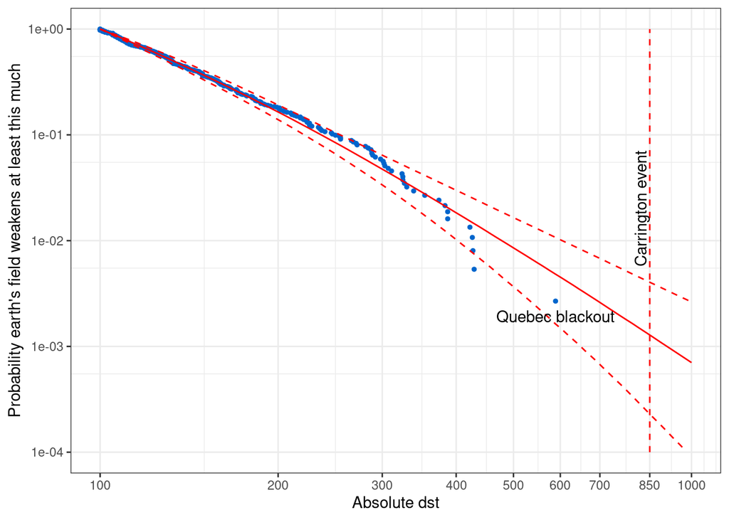

[output not shown]

```r
library(rstan)
library(bayesplot)
library(loo)
gpd_params <- rstan::extract(fit_gpd)
mu <- apply(t(gpd_params$predccdf), 1, quantile, c(0.05, 0.5, 0.95)) %>%
  t() %>% data.frame(x = yt, .) %>% gather(pct, y, -x)

clrs <- color_scheme_get("brightblue")
ggplot() +
  geom_point(aes(dst, ccdf), data = d, size = 1, color = clrs[[5]]) +
  geom_line(aes(x=c(850,850),y=c(1e-4,1)),linetype="dashed",color="red") +
  geom_line(aes(x, y, linetype = pct), data = mu, color = 'red') +
  scale_linetype_manual(values = c(2,1,2)) +
  coord_trans(x="log10", y="log10", limx=c(100,1000), limy=c(1e-4,1)) +
  scale_y_continuous(breaks=c(1e-5,1e-4,1e-3,1e-2,1e-1,1), limits=c(1e-4,1)) +
  scale_x_continuous(breaks=c(100,200,300,400,500,600,700,850,1000), limits=c(100,1000)) +
  geom_text(aes(x = d$dst[n], y = d$ccdf[n]), label = "Quebec blackout", vjust="top", nudge_y=-0.0005) +
  geom_text(aes(x = 820, y = 0.02), label = "Carrington event", angle=90) +
  labs(y = "Probability earth's field weakens at least this much", x= "Absolute dst") +
  guides(linetype = F) +
  theme_bw()
```